# Property Price Prediction

## 2.3 Additional insights and issues

# 3. Modelling

## 3.1 Explain your analysis plan

I will Build 3 models to predict property prices and based of analysis of output of them, I will finalise my model. I will use maximal model, minimal adequate model using step function and a model in which dependent variable price will be converted in to log value for transformation, and then it will be used in model.

After then, I will Evaluate the model and finally, write findings of them.

## 3.2 Build a model for property price

Using the continuous explanatory variables decide on a maximal model

Converting type in to numeric from factor, before using in modeling.

```r
newdf$n_bathrooms = as.numeric(newdf$n_bathrooms)
newdf$floor = as.numeric(newdf$floor)
newdf$n_rooms = as.numeric(newdf$n_rooms)
newdf$is_furnished = as.numeric(newdf$is_furnished)
```

**Model 1**

```r
property_price.lm<-lm(newdf$price~newdf$mq+newdf$n_rooms+newdf$n_bathrooms+newdf$floor+newdf$is_furnished)

summary(property_price.lm) #maximal model
```

```
Call:
lm(formula = newdf$price ~ newdf$mq + newdf$n_rooms + newdf$n_bathrooms +
    newdf$floor + newdf$is_furnished)

Residuals:
    Min      1Q  Median      3Q     Max
-279625  -57642  -14214   41180  375713

Coefficients:
                   Estimate Std. Error t value Pr(>|t|)
(Intercept)         6423.99   16500.11   0.389   0.6971
newdf$mq             332.89      41.07   8.106 1.71e-15 ***
newdf$n_rooms       7780.18    3484.60   2.233   0.0258 *
newdf$n_bathrooms  47230.73    5756.92   8.204 8.05e-16 ***
newdf$floor         4936.09    2649.83   1.863   0.0628 .
newdf$is_furnished  5169.47   12632.63   0.409   0.6825
---
Signif. codes:  0 ‘***’ 0.001 ‘**’ 0.01 ‘*’ 0.05 ‘.’ 0.1 ‘ ’ 1

Residual standard error: 88970 on 894 degrees of freedom
Multiple R-squared:  0.2448,    Adjusted R-squared:  0.2405
F-statistic: 57.94 on 5 and 894 DF,  p-value: < 2.2e-16
```

Model 1 has R-squared: 0.2448, F-statistic: 57.94, p-value: < 2.2e-16 Model 1 can be considered as good model.

**Using model selection approach to achieve a minimal adequate model using step function**

Initially I will use all the continuous variables as explanatory variables as my starting maximal model. Then use the step function

```r
step(property_price.lm)
```

```
Start:  AIC=20518.92
newdf$price ~ newdf$mq + newdf$n_rooms + newdf$n_bathrooms +
    newdf$floor + newdf$is_furnished

                     Df  Sum of Sq        RSS   AIC
- newdf$is_furnished  1 1.3256e+09 7.0783e+12 20517
<none>                             7.0770e+12 20519
- newdf$floor         1 2.7469e+10 7.1044e+12 20520
- newdf$n_rooms       1 3.9462e+10 7.1164e+12 20522
- newdf$mq            1 5.2018e+11 7.5971e+12 20581
- newdf$n_bathrooms   1 5.3282e+11 7.6098e+12 20582

Step:  AIC=20517.09
newdf$price ~ newdf$mq + newdf$n_rooms + newdf$n_bathrooms +
    newdf$floor

                    Df  Sum of Sq        RSS   AIC
<none>                            7.0783e+12 20517
- newdf$floor        1 2.8208e+10 7.1065e+12 20519
- newdf$n_rooms      1 4.0204e+10 7.1185e+12 20520
- newdf$mq           1 5.2038e+11 7.5987e+12 20579
- newdf$n_bathrooms  1 5.3199e+11 7.6103e+12 20580

Call:
lm(formula = newdf$price ~ newdf$mq + newdf$n_rooms + newdf$n_bathrooms +
    newdf$floor)

Coefficients:
      (Intercept)           newdf$mq      newdf$n_rooms  newdf$n_bathrooms        newdf$floor
          11691.3              332.9             7844.9            47185.7             4994.8
```

The step function has ended with this minimal adequate model with the lowest AIC value that is 20517.09.

newdf$price ~ newdf$mq + newdf$n_rooms + newdf$n_bathrooms + newdf$floor

$$Price = 11691.3 + 332.9\times mq\ (area)
+ 7844.9 \times \ number \ of \ rooms + 47185.7 \times \ number \ of \
bathroom + 4994.8 \times \ number \ of \ floor$$

**Model 2**

```r
min_property_price.lm<-lm(formula = newdf$price ~ newdf$mq + newdf$n_rooms + newdf$n_bathrooms + newdf$floor)
summary(min_property_price.lm)
```

```
Call:
lm(formula = newdf$price ~ newdf$mq + newdf$n_rooms + newdf$n_bathrooms +
    newdf$floor)

Residuals:
    Min      1Q  Median      3Q     Max
-279857  -56912  -14506   40886  375467

Coefficients:
                  Estimate Std. Error t value Pr(>|t|)
(Intercept)       11691.33   10318.50   1.133   0.2575
newdf$mq            332.95      41.05   8.112 1.64e-15 ***
newdf$n_rooms      7844.85    3479.39   2.255   0.0244 *
newdf$n_bathrooms 47185.69    5753.19   8.202 8.19e-16 ***
newdf$floor        4994.77    2644.72   1.889   0.0593 .
---
Signif. codes:  0 ‘***’ 0.001 ‘**’ 0.01 ‘*’ 0.05 ‘.’ 0.1 ‘ ’ 1

Residual standard error: 88930 on 895 degrees of freedom
Multiple R-squared:  0.2446,    Adjusted R-squared:  0.2412
F-statistic: 72.45 on 4 and 895 DF,  p-value: < 2.2e-16
```

$$Property Price= 11691.33 + 332.95\times
mq\ (area) + 7844.85 \times \ number \ of \ rooms + 47185.69 \times \
number \ of \ bathroom + 4994.77 \times floor$$

R-squared: 0.2446 The R-squared is the ratio of the variance in a dependent variable to that explained by the independent variable(s) in a regression model. A value of 0 indicates that the model does not explain any of the variables in the dependent variable, and a value of 1 indicates that it explains all of them.

F-statistic: 72.45 The F-statistic is a measure of the overall significance of the regression model. It is calculated as the ratio of the mean square explained by the model to its residual, or error. If the p-value is smaller than 0.05, then the relationship is considered statistically significant the model is considered to be a good fit for the data.

The value of the F-statistic = 72.45 shows that it can be good fit model.

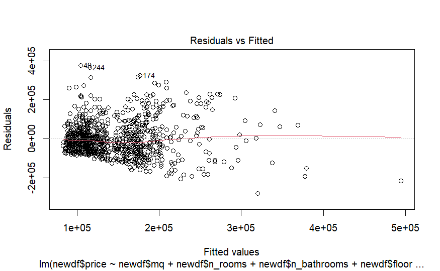

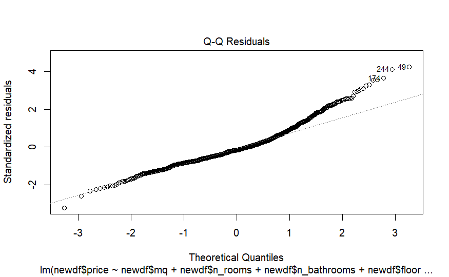

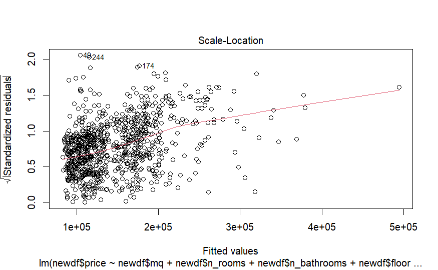

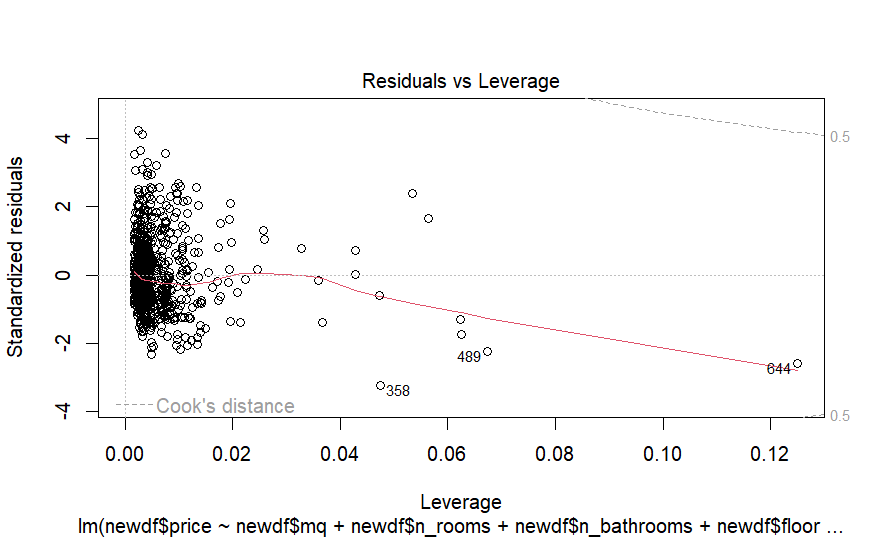

```r
plot(min_property_price.lm)
```

**Residuals vs Fitted**

As data move ahead in x axis, data start bursting more and more, which indicates that relationship between the independent and dependent variables is non-linear. In this case, non-linear model would be better fit for data.

**normal Q-Q plot (quantile-quantile plot)** Normal Q-Q plot indicate that the sample is not from a population with a normal distribution. The deviation from the line may be caused by the presence of outliers or by a skewed distribution.

**Scale Location** Scale-location plot indicates that the variance of the errors is not constant and that the assumption of homoscedasticity is not met. This pattern may be caused by a non-linear relationship between the independent and dependent variables or by the presence of outliers.

**Residuals vs Leverage** A residuals vs leverage plot result indicates that most of the observations in the dataset are not influential and have a small leverage, while a few observations have a large leverage and may be influential. These influential observations may have a disproportionate effect on the fit of the model and may need to be carefully examined.

**Model 3**

Now we will convert property price to log value to make it normalized and use it in to maximal model.

```r
prop_price_log.lm<-lm(log(newdf$price)~newdf$mq+newdf$n_rooms+newdf$n_bathrooms+newdf$floor+newdf$is_furnished)

summary(prop_price_log.lm) #maximal if you add all coloumns except binary
```

```
Call:
lm(formula = log(newdf$price) ~ newdf$mq + newdf$n_rooms + newdf$n_bathrooms +
    newdf$floor + newdf$is_furnished)

Residuals:
     Min       1Q   Median       3Q      Max
-2.93753 -0.39002  0.06667  0.44270  1.69721

Coefficients:
                    Estimate Std. Error t value Pr(>|t|)
(Intercept)        1.076e+01  1.218e-01  88.295  < 2e-16 ***
newdf$mq           1.870e-03  3.032e-04   6.167 1.05e-09 ***
newdf$n_rooms      6.838e-02  2.573e-02   2.658   0.0080 **
newdf$n_bathrooms  2.858e-01  4.250e-02   6.725 3.13e-11 ***
newdf$floor        4.332e-02  1.956e-02   2.214   0.0271 *
newdf$is_furnished 2.261e-02  9.326e-02   0.242   0.8085
---
Signif. codes:  0 ‘***’ 0.001 ‘**’ 0.01 ‘*’ 0.05 ‘.’ 0.1 ‘ ’ 1

Residual standard error: 0.6568 on 894 degrees of freedom
Multiple R-squared:  0.184, Adjusted R-squared:  0.1795
F-statistic: 40.32 on 5 and 894 DF,  p-value: < 2.2e-16
```

Then, I will use the step function to get to our *minimal adequate model*, we do this instead of going step by step manually as we did before.

```r
m3_prop_price_log.lm<-step(prop_price_log.lm)
```

```
Start:  AIC=-750.56
log(newdf$price) ~ newdf$mq + newdf$n_rooms + newdf$n_bathrooms +
    newdf$floor + newdf$is_furnished

                     Df Sum of Sq    RSS     AIC
- newdf$is_furnished  1    0.0254 385.74 -752.50
<none>                            385.72 -750.56
- newdf$floor         1    2.1153 387.83 -747.64
- newdf$n_rooms       1    3.0483 388.76 -745.48
- newdf$mq            1   16.4110 402.13 -715.06
- newdf$n_bathrooms   1   19.5123 405.23 -708.15

Step:  AIC=-752.5
log(newdf$price) ~ newdf$mq + newdf$n_rooms + newdf$n_bathrooms +
    newdf$floor

                    Df Sum of Sq    RSS     AIC
<none>                           385.74 -752.50
- newdf$floor        1    2.1468 387.89 -749.51
- newdf$n_rooms      1    3.0799 388.82 -747.35
- newdf$mq           1   16.4160 402.16 -716.99
- newdf$n_bathrooms  1   19.4926 405.23 -710.14
```

```r
summary(m3_prop_price_log.lm)
```

```
Call:
lm(formula = log(newdf$price) ~ newdf$mq + newdf$n_rooms + newdf$n_bathrooms +
    newdf$floor)

Residuals:
     Min       1Q   Median       3Q      Max
-2.93895 -0.39181  0.06559  0.44144  1.69613

Coefficients:
                   Estimate Std. Error t value Pr(>|t|)
(Intercept)       10.778635   0.076173 141.502  < 2e-16 ***
newdf$mq           0.001870   0.000303   6.172 1.02e-09 ***
newdf$n_rooms      0.068663   0.025685   2.673  0.00765 **
newdf$n_bathrooms  0.285622   0.042471   6.725 3.13e-11 ***
newdf$floor        0.043573   0.019524   2.232  0.02588 *
---
Signif. codes:  0 ‘***’ 0.001 ‘**’ 0.01 ‘*’ 0.05 ‘.’ 0.1 ‘ ’ 1

Residual standard error: 0.6565 on 895 degrees of freedom
Multiple R-squared:  0.184, Adjusted R-squared:  0.1803
F-statistic: 50.44 on 4 and 895 DF,  p-value: < 2.2e-16
```

R-squared value = 0.184 and F-statistic = 50.44 and p-value: < 2.2e-16

log(newdf$price) ~ newdf$mq + newdf$n_rooms + newdf$n_bathrooms + newdf$floor)

## 3.3 Critique model using relevant diagnostics

Model 1:

This model includes 5 predictor variables: mq, n_rooms, n_bathrooms, floor, and is_furnished.

The R-squared value for the model 1 is 0.2448, which suggests that the model explains about 24.5% of the variance in the dependent variable newdf$price. The residual standard error for the model is 88970. A smaller residual standard error indicates a better fit of the model to the data. The p-value for the F-statistic is less than 2.2e-16, which suggests that the model is a good fit for the data.

Model 2

This model includes 4 predictor variables: mq, n_rooms, n_bathrooms, and floor. The R-squared value for the model 2 is 0.2446, which is slightly lower than the R-squared value for Model 1. This suggests that the inclusion of the predictor variable is_furnished in Model 1 did not significantly improve the fit of the model.

The residual standard error for the model is 88930, which is slightly lower than the residual standard error for Model 1. This indicates a slightly better fit of the model to the data. value of F-statistic is 72.45 and the p-value for the F-statistic is less than 2.2e-16, which suggests that the model is a good fit for the data.

Model 2 Formula :

$$Property Price= 11691.33 + 332.95\times
mq\ (area) + 7844.85 \times \ number \ of \ rooms + 47185.69 \times \
number \ of \ bathroom + 4994.77 \times floor$$

Model 3:

This model includes 4 predictor variables: mq, n_rooms, n_bathrooms, and floor. The dependent variable in this model is the natural logarithm of price. Taking the logarithm of the dependent variable can be useful in cases where the data exhibits a skewed distribution or when the relationship between the variables is non-linear.

As per my opinion, Model 2 is the best model in all of 3 models. As in Model 2, it’s perfect balance between R-squared value (0.2446) and F statistics 72.45 .

/

## 3.4 Suggest improvements to your model

There are many ways to improve a model. Here are a few suggestions:

Increase the sampling: Increasing the sampling is one of the best ways to enhance the performance of the model. It will aid in the normalisation of the data and allow us to lessen its skewness.

Improve Feature selection: Along with quantity, data quality is crucial. Data scientists will have the opportunity to analyse the data in a variety of ways using various features if it has more features.

Avoid bias in data: We should make every effort to avoid bias when collecting data.

Avoid Co-Linearity: Before fitting data to a model, avoid co-linearity.

Try to normalize the data: Standardize the data using different methods such as log, square root, or cube root.